# Organismal Responses to Change: Adapt

## Are organisms ‘shape-shifting’ to climate change?

- **Animals are altering their morphology—especially body size and extremity proportions—as a response to climate change.**
  - This phenomenon is consistent with two complementary ecogeographical rules:

**Bergmann’s Rule: body sizes adapt differently to climate**  
**Allen’s Rule: body part sizes adapt differently to climate**

**These changes may represent phenotypic plasticity, evolutionary adaptation, or both**

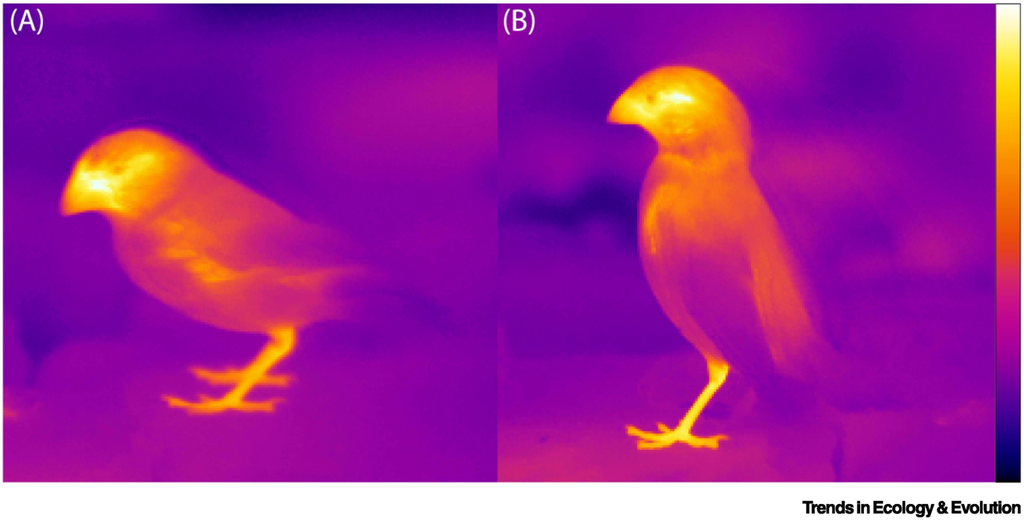

## Bergmann’s Rule and body size

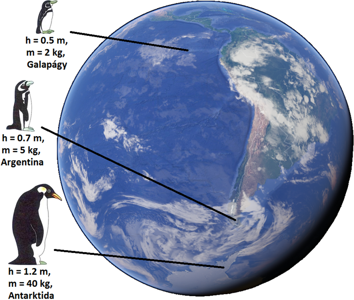

## Allens’s Rule and body size

- **Within endothermic animals, species in colder climates tend to have shorter extremities compared to their counterparts in warmer climates**
- **Shorter length reduces surface area, minimizing heat loss, which is important in cold environments**
  - shorter ears, tails, and limbs are common
- **Arctic foxes have shorter ears and legs compared to desert foxes**
- **Birds in hot, tropical northern Australia have longer bills than birds in temperate, southern Australia**

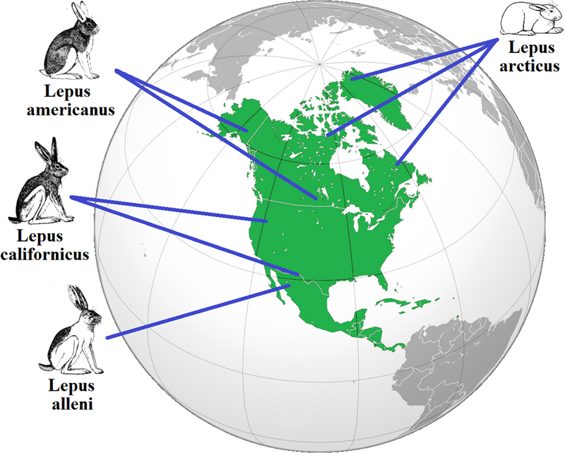

## Non-animal species shift morphology too, just differently

- **Some plants have shifted leaf size, shape, or thickness for water conservation**
  - shifts in leaf traits has long evolutionary history
- **Some plants have altered root distributions and branching in response to drought/flooding**
- **Cell size for bacteria/protists (single-celled organisms) reduced with climate warming**
- **These changes may represent phenotypic plasticity, evolutionary adaptation, or both**

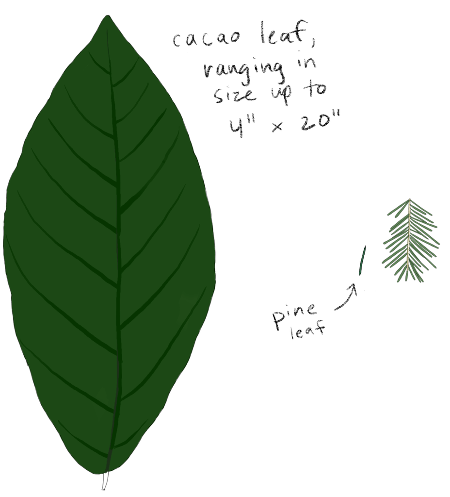

## Evolution can be fast (but not usually)

- **The rate of adaptation is influenced by a combination of biological and ecological factors:**
  - *Generation Time*: Short generations (e.g., insects, bacteria) allow more opportunities for selection
  - *Genetic Variation*: Evolution requires existing variation
  - *Mutation Rate*: High mutation rates can introduce new traits
  - *Population Size*: Larger populations have more variation
- **Another thing to consider: How powerful is the environmental selection?**

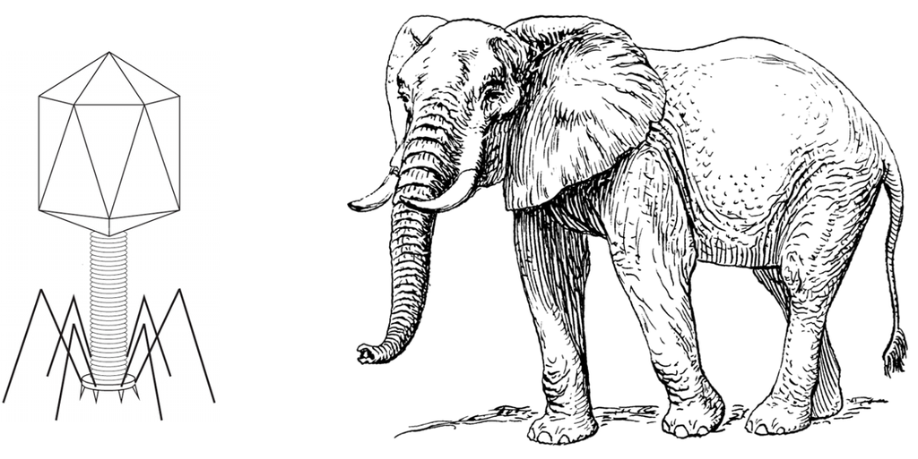

## Evolution can be fast (but not usually)

- **Case Study (Eastern Red-backed Salamander)**
  - Color morphs (red-backed vs. lead-backed) show variation across elevation, forest cover, and temperature gradients
  - Lead-backed morph more frequent in warmer, fragmented forests
  - Could be natural selection favoring heat-tolerant morphs as forests warm
  - shifts have occurred over the past several decades (fast)
- **Not all populations show the same shift**
  - suggests local adaptation or constraints

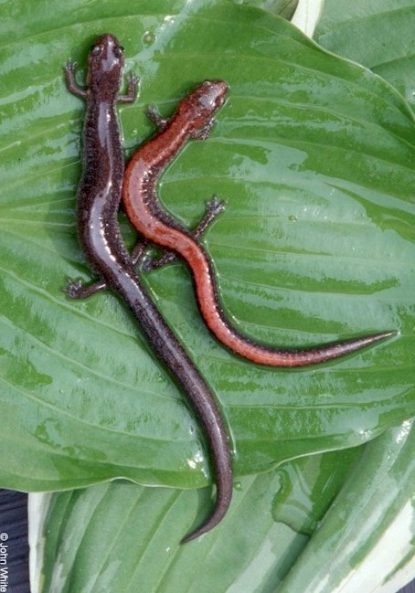

## Is rapid-evolution occurring in Elephants due to poaching?

- **Intense ivory poaching pressure (human-driven selection) of Savannah elephants has reduced populations**
  - poachers prefer elephants with large tusks
- **Some females are born without tusks, due to mutations on several genes**
  - similar genes to teeth traits in humans
- **Ivory poaching disproportionately removes tusked individuals from the breeding population**
  - Removing tusks without killing the animal is nearly impossible

[figure not shown]

## Microevolution: Rapid selection of tuskless female elephants

**The survival of tuskless females across this 28-year period was estimated to five times that of tusked individuals in Gorongosa National Park (Campbell-Station et al. 2021)**

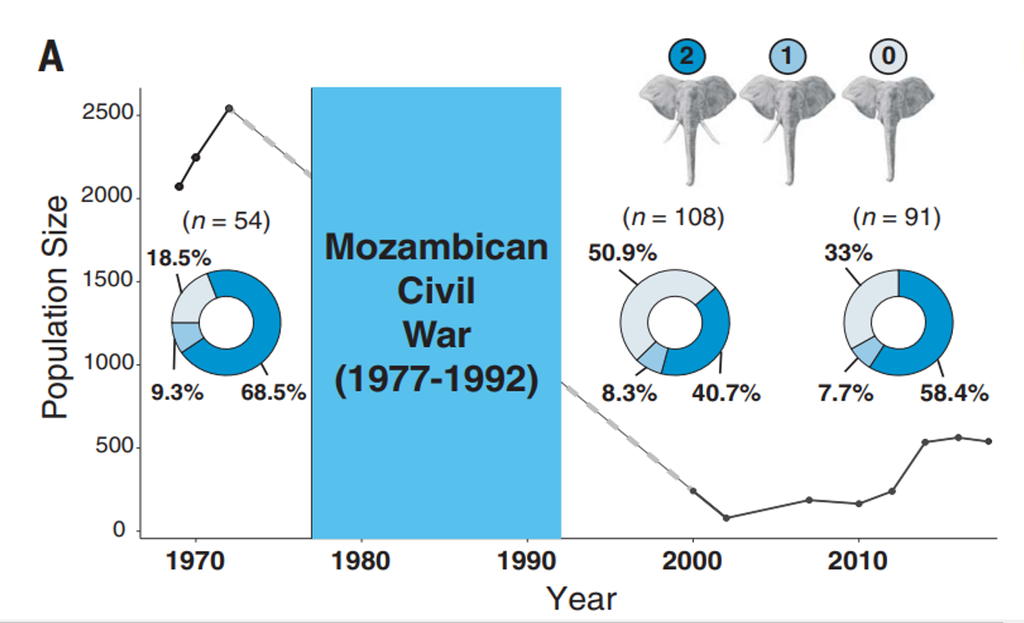

## Measuring rapid evolution in water fleas

**Question: Can *Daphnia* evolve to cope with global warming?**

**Approach 1: Experimental evolution**

**Approach 2: Resurrection ecology**

**CTmax - upper threshold of temperature that an organism can function normally**

[figure not shown]

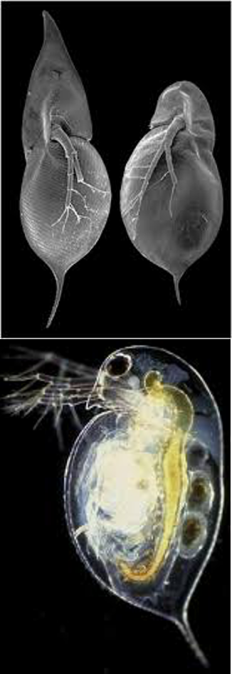

## Measuring rapid evolution in water fleas

**Approach 1: Experimental evolution - Evolved *Daphnia* under control and warmed conditions for 2 years**

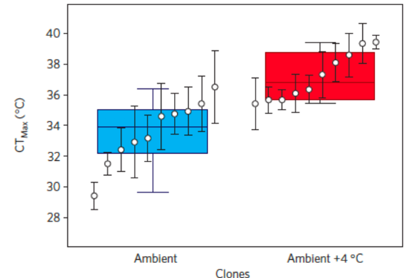

## Measuring rapid evolution in water fleas

**Approach 2: Resurrection ecology - Hatched *Daphnia* from historic and contemporary sediment layers**

**Conclusion: Thermal tolerance in *Daphnia* can evolve over short time scales in response to warming**

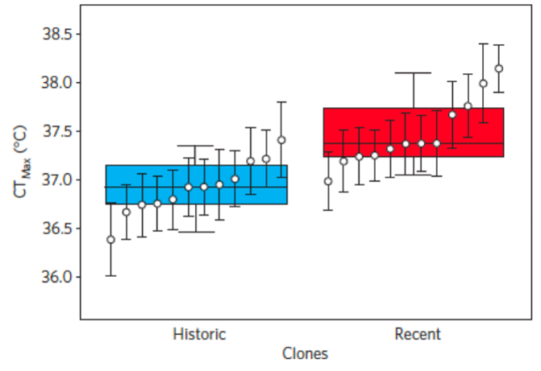

## Urban evolution in real time?

- **White-footed mouse thrive in both Appalachian forests and urban areas in the eastern US**
- **In urban areas, populations have evolved genetic changes to detoxify pollutants and enable metabolism of high-fat human foods**
- **Studies show evolutionary divergence in less than 100 generations**
- **Test yourself: Which adjacent possible has occurred in urban populations?**

[figure not shown]

## Measure it: Urban eolution in real time?

**Is the urban mouse population genetically adapted or just exhibiting phenotypic plasticity?**

**Could a common garden experiment (raising forest and urban mice in the same conditions) help isolate genetic effects?**

**What outcomes would suggest plasticity?**

**What outcomes would suggest evolution by natural selection?**

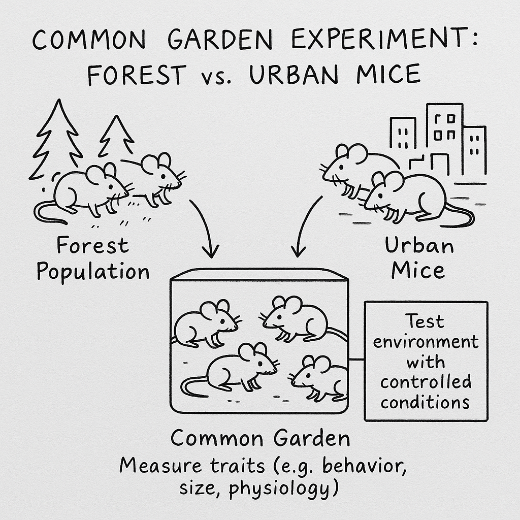

## BIG QUESTION: Can adaptation prevent extinction?

[figure not shown]

## BIG QUESTION: Can adaptation prevent extinction?

- **Evolutionary rescue = process by which a population—that would have gone extinct in the absence of evolution—persist due to natural selection**
- **So far, not been shown to be common in nature**
  - cricket versus invasive fly parasitoid
- **Experimentally - more common**
  - yeast evolving to tolerate previously lethal salt concentrations
- **Can species adapt to multiple global change stressors?**

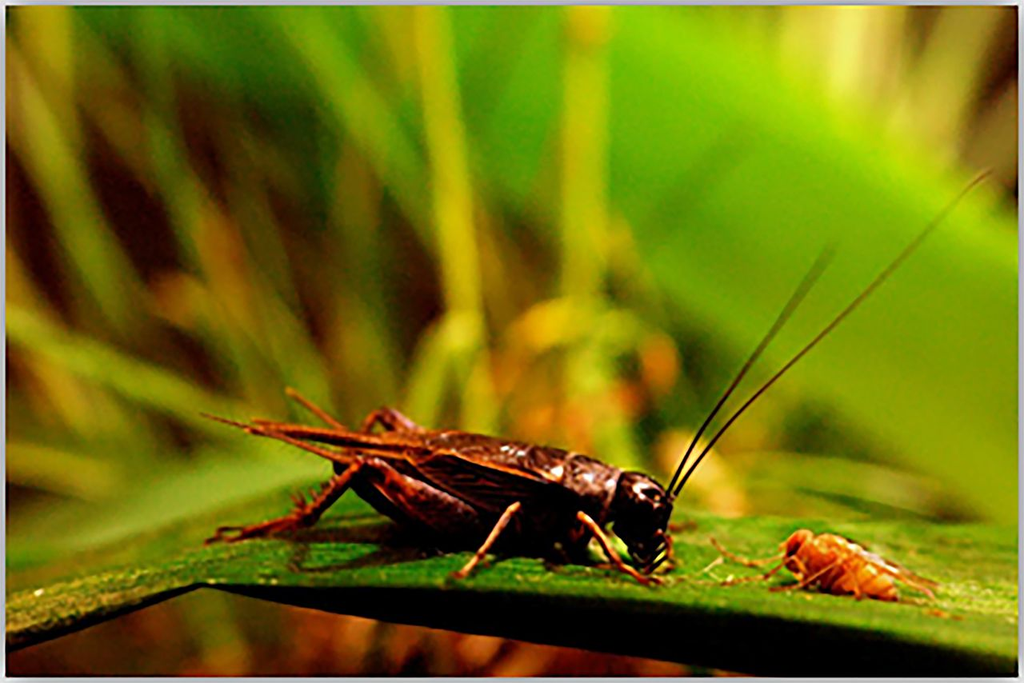

## Assisted evolutionary rescue…

- **Spreading Avens is an Appalachian endangered plant, found only on high-elevation peaks**
  - found in western NC and eastern Tennessee
- **Vulnerable to extinction due to climate change, land development and outdoor recreation (climbing)**
- **Researchers have breed the small isolated populations of Spreading Avens with more diverse populations to create hybrids**
  - hybrids may gain traits (↑ adaptive potential) to allow them to survive
- **To speed up evolutionary rescue, what should our role be?**

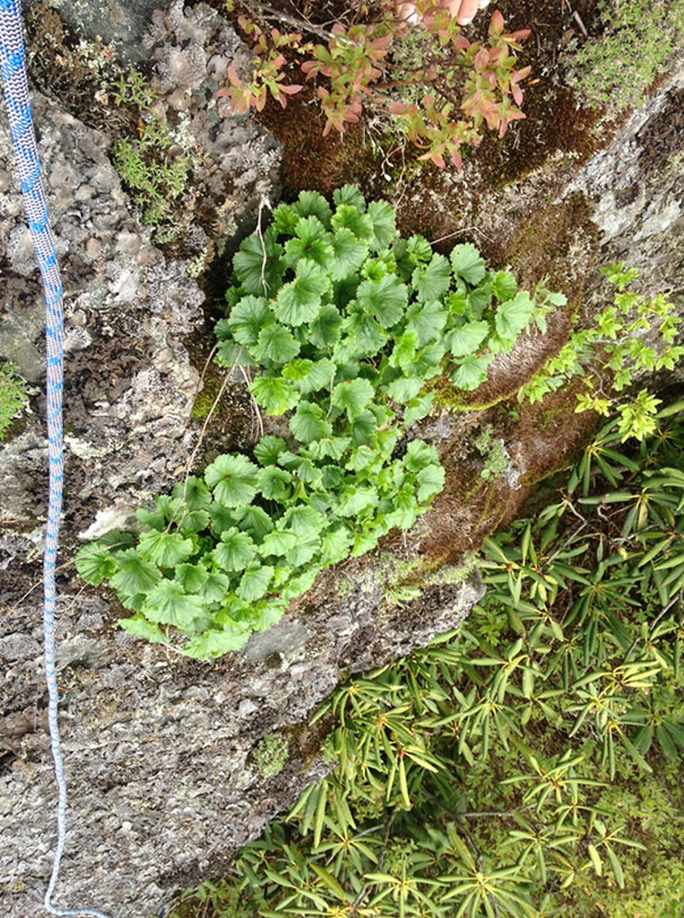

## What are there limits to adaptation?

- **Standing genetic variation** is the existing pool of traits in a population
  - Natural selection can only act on traits that already exist
  - Species with high standing variation are more likely to adapt quickly to global change

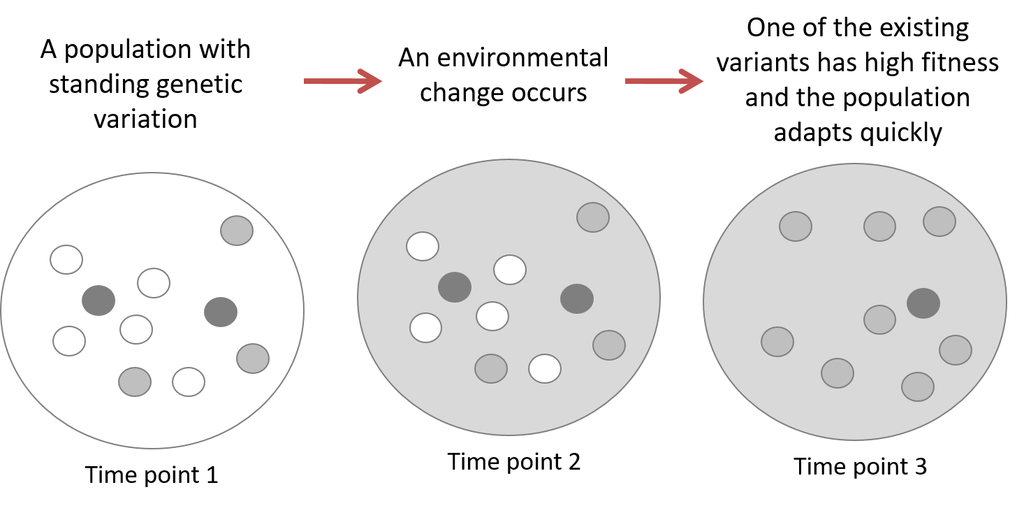

## What are there limits to adaptation?

- **Species with low variation may have no evolutionary “tools” available to respond**
  - Long-lived species or reduced populations often have reduced variation
  - environmental change may occur to quickly before a beneficial mutation arises

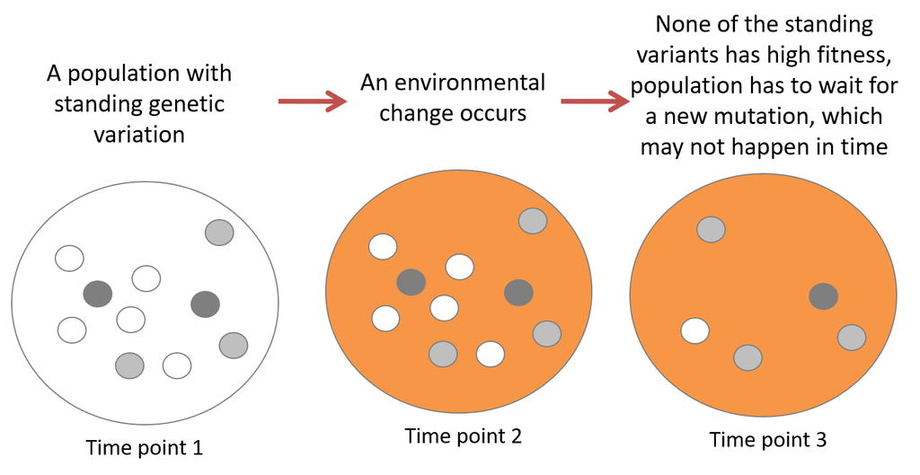

## Evolution Case study: American chestnut

**Chestnut blight (fungus) was introduced to North America from Asia in the early 1900s.**

- **American chestnuts were once widespread and dominant in eastern forests—including Appalachia**
  - had no prior exposure to this pathogen
  - lacked genetic resistance to the fungus
- **Despite being genetically diverse overall, they had no existing resistance alleles**
  - standing variation for the trait under selection = 0
- **The entire population was uniformly vulnerable, and blight wiped out ~4 billion trees within decades**
  - trees reproduce to slowly for mutations to create an adaptive solution

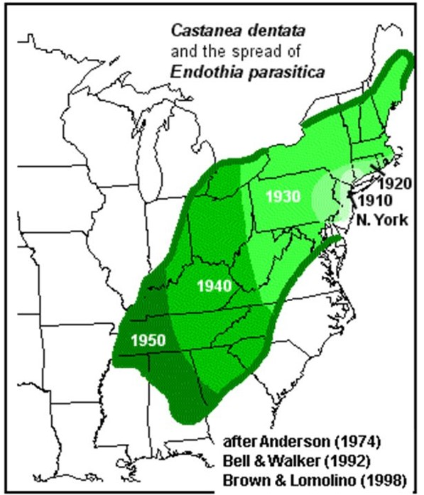

## Can Species Adapt to More Than One Challenge?

- **Adapting to multiple stressors often requires multiple traits**
  - Species rarely face just one threat—global change is multi-factorial:
    - Climate warming, habitat loss, invasive species, pollution, harvesting
- **Many species have limited standing variation—not enough to evolve all needed traits at once**
- **Appalachian Brook Trout may need to adapt thermal tolerance, disease resistance, altered spawning timing**
  - Even if variation exists for one trait, adaptation can fail if other traits can’t respond
  - isolated headwater populations tend to have low genetic variation

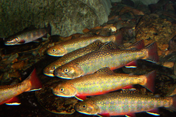

## Gene Flow: A Lifeline for Adaptation…

- **Gene flow is the movement of genes between *connected* populations through migration and reproduction**
  - introduces new alleles into a population
  - alternative to local mutations or standing variation
- **But only works if populations are connected**
- **Appalachian Brook Trout populations are fragmented from roads, habitat loss, warming, drought**
  - gene flow could be restored through through conservation

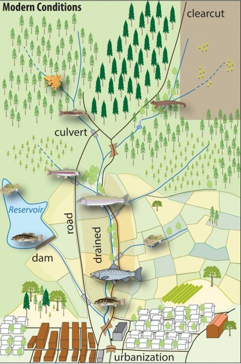

## Not All Evolutionary Change is Adaptive

- **Genetic drift is random change in allele frequencies over time, unrelated to fitness or selection**
  - reminder: alleles = alternate versions of a gene
  - usually results in alleles being lost
- **Powerful evolutionary in small populations, where chance events can quickly shift genetic makeup**
  - habitat loss and fragmentation can severely reduce population sizes
  - reduces adaptive potential, makes populations more vulnerable to change
- **Brook trout in fragmented isolated Appalachian streams may lose rare alleles just by chance**
  - any deaths may mean a helpful trait disappears

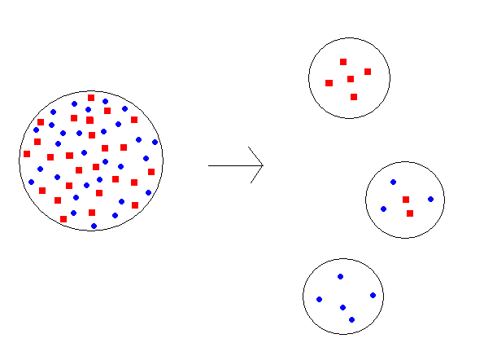

## Genetic drift can interfere with natural selection

**Global change can reshape the gene pool randomly, without improving fitness**

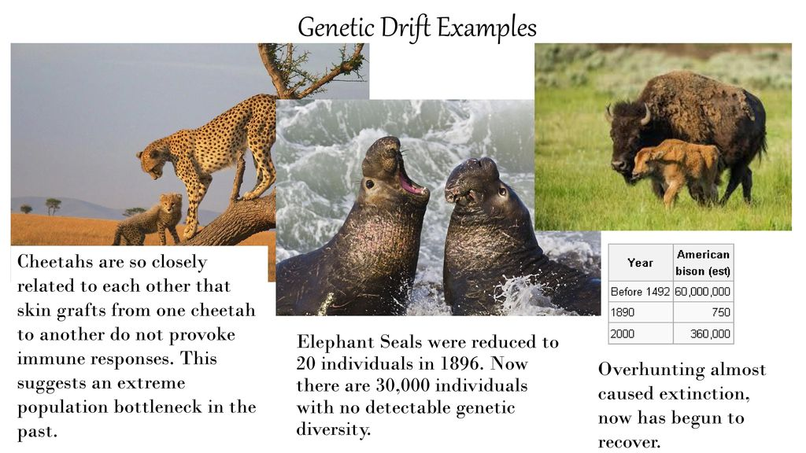